# Risk Factor Analysis

## Outcome Variable

**Outcome Variable:** whz

## Predictor Variables

**Intervention Variable:** safeh20

**Adjustment Set:**

- arm
- sex
- W_mage
- meducyrs
- feducyrs
- hhwealth_quart
- hfoodsec
- W_mhtcm
- W_mwtkg
- W_mbmi
- W_nrooms
- W_nchldlt5
- W_parity
- impfloor
- impsan
- delta_W_mage
- delta_meducyrs
- delta_feducyrs
- delta_hhwealth_quart
- delta_hfoodsec
- delta_W_mhtcm
- delta_W_mwtkg
- delta_W_mbmi
- delta_W_nrooms
- delta_W_nchldlt5
- delta_W_parity
- delta_impfloor
- delta_impsan

## Stratifying Variables

The analysis was stratified on these variable(s):

- agecat
- studyid
- country

## Data Summary

| agecat | studyid | country | safeh20 | n_cell | n | outcome_variable |
| --- | --- | --- | --- | --- | --- | --- |
| Birth | ki0047075b-MAL-ED | BANGLADESH | 1 | 0 | 201 | whz |
| Birth | ki0047075b-MAL-ED | BANGLADESH | 0 | 201 | 201 | whz |
| Birth | ki0047075b-MAL-ED | BRAZIL | 1 | 0 | 38 | whz |
| Birth | ki0047075b-MAL-ED | BRAZIL | 0 | 38 | 38 | whz |
| Birth | ki0047075b-MAL-ED | INDIA | 1 | 0 | 39 | whz |
| Birth | ki0047075b-MAL-ED | INDIA | 0 | 39 | 39 | whz |
| Birth | ki0047075b-MAL-ED | NEPAL | 1 | 1 | 25 | whz |
| Birth | ki0047075b-MAL-ED | NEPAL | 0 | 24 | 25 | whz |
| Birth | ki0047075b-MAL-ED | PERU | 1 | 9 | 202 | whz |
| Birth | ki0047075b-MAL-ED | PERU | 0 | 193 | 202 | whz |
| Birth | ki0047075b-MAL-ED | SOUTH AFRICA | 1 | 13 | 95 | whz |
| Birth | ki0047075b-MAL-ED | SOUTH AFRICA | 0 | 82 | 95 | whz |
| Birth | ki0047075b-MAL-ED | TANZANIA, UNITED REPUBLIC OF | 1 | 74 | 111 | whz |
| Birth | ki0047075b-MAL-ED | TANZANIA, UNITED REPUBLIC OF | 0 | 37 | 111 | whz |
| Birth | ki1017093-NIH-Birth | BANGLADESH | 1 | 573 | 575 | whz |
| Birth | ki1017093-NIH-Birth | BANGLADESH | 0 | 2 | 575 | whz |
| Birth | ki1017093b-PROVIDE | BANGLADESH | 1 | 45 | 45 | whz |
| Birth | ki1017093b-PROVIDE | BANGLADESH | 0 | 0 | 45 | whz |
| Birth | ki1017093c-NIH-Crypto | BANGLADESH | 1 | 707 | 707 | whz |
| Birth | ki1017093c-NIH-Crypto | BANGLADESH | 0 | 0 | 707 | whz |
| Birth | kiGH5241-JiVitA-3 | BANGLADESH | 1 | 17963 | 17992 | whz |
| Birth | kiGH5241-JiVitA-3 | BANGLADESH | 0 | 29 | 17992 | whz |
| Birth | kiGH5241-JiVitA-4 | BANGLADESH | 1 | 2394 | 2394 | whz |
| Birth | kiGH5241-JiVitA-4 | BANGLADESH | 0 | 0 | 2394 | whz |
| 6 months | ki0047075b-MAL-ED | BANGLADESH | 1 | 0 | 240 | whz |
| 6 months | ki0047075b-MAL-ED | BANGLADESH | 0 | 240 | 240 | whz |
| 6 months | ki0047075b-MAL-ED | BRAZIL | 1 | 0 | 142 | whz |
| 6 months | ki0047075b-MAL-ED | BRAZIL | 0 | 142 | 142 | whz |
| 6 months | ki0047075b-MAL-ED | INDIA | 1 | 0 | 235 | whz |
| 6 months | ki0047075b-MAL-ED | INDIA | 0 | 235 | 235 | whz |

[output cut: 52 more lines]

The following strata were considered:

- agecat: 24 months, studyid: ki0047075b-MAL-ED, country: BANGLADESH
- agecat: 24 months, studyid: ki0047075b-MAL-ED, country: BRAZIL
- agecat: 24 months, studyid: ki0047075b-MAL-ED, country: INDIA
- agecat: 24 months, studyid: ki0047075b-MAL-ED, country: NEPAL
- agecat: 24 months, studyid: ki0047075b-MAL-ED, country: PERU
- agecat: 24 months, studyid: ki0047075b-MAL-ED, country: SOUTH AFRICA
- agecat: 24 months, studyid: ki0047075b-MAL-ED, country: TANZANIA, UNITED REPUBLIC OF
- agecat: 24 months, studyid: ki1017093-NIH-Birth, country: BANGLADESH
- agecat: 24 months, studyid: ki1017093b-PROVIDE, country: BANGLADESH
- agecat: 24 months, studyid: ki1017093c-NIH-Crypto, country: BANGLADESH
- agecat: 24 months, studyid: ki1114097-CONTENT, country: PERU
- agecat: 24 months, studyid: ki1148112-LCNI-5, country: MALAWI
- agecat: 24 months, studyid: kiGH5241-JiVitA-3, country: BANGLADESH
- agecat: 24 months, studyid: kiGH5241-JiVitA-4, country: BANGLADESH
- agecat: 6 months, studyid: ki0047075b-MAL-ED, country: BANGLADESH
- agecat: 6 months, studyid: ki0047075b-MAL-ED, country: BRAZIL
- agecat: 6 months, studyid: ki0047075b-MAL-ED, country: INDIA
- agecat: 6 months, studyid: ki0047075b-MAL-ED, country: NEPAL
- agecat: 6 months, studyid: ki0047075b-MAL-ED, country: PERU
- agecat: 6 months, studyid: ki0047075b-MAL-ED, country: SOUTH AFRICA
- agecat: 6 months, studyid: ki0047075b-MAL-ED, country: TANZANIA, UNITED REPUBLIC OF
- agecat: 6 months, studyid: ki1000304b-SAS-FoodSuppl, country: INDIA
- agecat: 6 months, studyid: ki1017093-NIH-Birth, country: BANGLADESH
- agecat: 6 months, studyid: ki1017093b-PROVIDE, country: BANGLADESH
- agecat: 6 months, studyid: ki1017093c-NIH-Crypto, country: BANGLADESH
- agecat: 6 months, studyid: ki1114097-CONTENT, country: PERU
- agecat: 6 months, studyid: ki1148112-LCNI-5, country: MALAWI
- agecat: 6 months, studyid: kiGH5241-JiVitA-3, country: BANGLADESH
- agecat: 6 months, studyid: kiGH5241-JiVitA-4, country: BANGLADESH
- agecat: Birth, studyid: ki0047075b-MAL-ED, country: BANGLADESH
- agecat: Birth, studyid: ki0047075b-MAL-ED, country: BRAZIL
- agecat: Birth, studyid: ki0047075b-MAL-ED, country: INDIA
- agecat: Birth, studyid: ki0047075b-MAL-ED, country: NEPAL
- agecat: Birth, studyid: ki0047075b-MAL-ED, country: PERU
- agecat: Birth, studyid: ki0047075b-MAL-ED, country: SOUTH AFRICA
- agecat: Birth, studyid: ki0047075b-MAL-ED, country: TANZANIA, UNITED REPUBLIC OF
- agecat: Birth, studyid: ki1017093-NIH-Birth, country: BANGLADESH
- agecat: Birth, studyid: ki1017093b-PROVIDE, country: BANGLADESH
- agecat: Birth, studyid: ki1017093c-NIH-Crypto, country: BANGLADESH
- agecat: Birth, studyid: kiGH5241-JiVitA-3, country: BANGLADESH
- agecat: Birth, studyid: kiGH5241-JiVitA-4, country: BANGLADESH

### Dropped Strata

- agecat: Birth, studyid: ki0047075b-MAL-ED, country: BANGLADESH
- agecat: Birth, studyid: ki0047075b-MAL-ED, country: BRAZIL
- agecat: Birth, studyid: ki0047075b-MAL-ED, country: INDIA
- agecat: Birth, studyid: ki0047075b-MAL-ED, country: NEPAL
- agecat: Birth, studyid: ki1017093-NIH-Birth, country: BANGLADESH
- agecat: Birth, studyid: ki1017093b-PROVIDE, country: BANGLADESH
- agecat: Birth, studyid: ki1017093c-NIH-Crypto, country: BANGLADESH
- agecat: Birth, studyid: kiGH5241-JiVitA-4, country: BANGLADESH
- agecat: 6 months, studyid: ki0047075b-MAL-ED, country: BANGLADESH
- agecat: 6 months, studyid: ki0047075b-MAL-ED, country: BRAZIL
- agecat: 6 months, studyid: ki0047075b-MAL-ED, country: INDIA
- agecat: 6 months, studyid: ki0047075b-MAL-ED, country: NEPAL
- agecat: 6 months, studyid: ki1000304b-SAS-FoodSuppl, country: INDIA
- agecat: 6 months, studyid: ki1017093-NIH-Birth, country: BANGLADESH
- agecat: 6 months, studyid: ki1017093b-PROVIDE, country: BANGLADESH
- agecat: 6 months, studyid: ki1017093c-NIH-Crypto, country: BANGLADESH
- agecat: 6 months, studyid: ki1114097-CONTENT, country: PERU
- agecat: 6 months, studyid: kiGH5241-JiVitA-4, country: BANGLADESH
- agecat: 24 months, studyid: ki0047075b-MAL-ED, country: BANGLADESH
- agecat: 24 months, studyid: ki0047075b-MAL-ED, country: BRAZIL
- agecat: 24 months, studyid: ki0047075b-MAL-ED, country: INDIA
- agecat: 24 months, studyid: ki0047075b-MAL-ED, country: NEPAL
- agecat: 24 months, studyid: ki1017093-NIH-Birth, country: BANGLADESH
- agecat: 24 months, studyid: ki1017093b-PROVIDE, country: BANGLADESH
- agecat: 24 months, studyid: ki1017093c-NIH-Crypto, country: BANGLADESH
- agecat: 24 months, studyid: ki1114097-CONTENT, country: PERU
- agecat: 24 months, studyid: kiGH5241-JiVitA-4, country: BANGLADESH

## Methods Detail

We’re interested in the causal parameters $E[Y_a]$ for all values of $a \in \mathcal{A}$. These parameters represent the mean outcome if, possibly contrary to fact, we intervened to set all units to have $A=a$. Under the randomization and positivity assumptions, these are identified by the statistical parameters $\psi_a=E_W[E_{Y|A,W}(Y|A=a,W)]$. In addition, we’re interested in the mean of $Y$, $E[Y]$ under no intervention (the observed mean). We will estimate these parameters by using SuperLearner to fit the relevant likelihood factors – $E_{Y|A,W}(Y|A=a,W)$ and $p(A=a|W)$, and then updating our likelihood fit using a joint TMLE.

For unadjusted analyses ($W=\{\}$), initial likelihoods were estimated using Lrnr_glm to estimate the simple $E(Y|A)$ and Lrnr_mean to estimate $p(A)$. For adjusted analyses, a small library containing Lrnr_glmnet, Lrnr_xgboost, and Lrnr_mean was used.

Having estimated these parameters, we will then use the delta method to estimate relative risks and attributable risks relative to a prespecified baseline level of $A$.

# Results Detail

## Results Plots

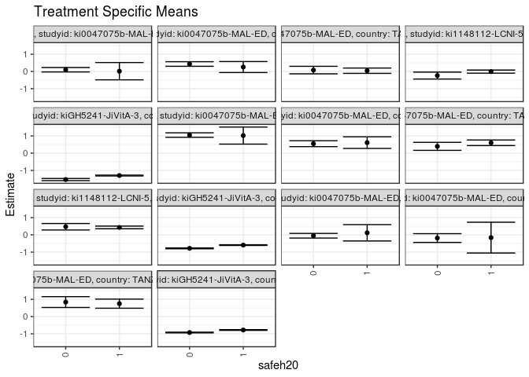

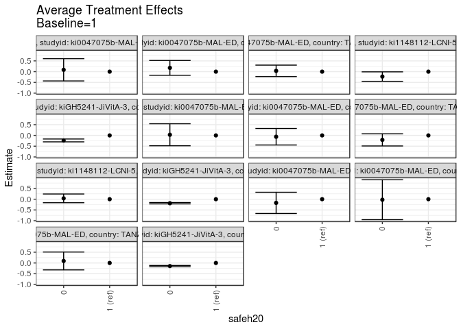

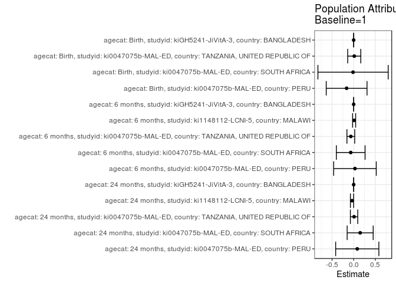

## Results Table

### Parameter: TSM

| agecat | studyid | country | intervention_level | baseline_level | estimate | ci_lower | ci_upper |
| --- | --- | --- | --- | --- | --- | --- | --- |
| Birth | ki0047075b-MAL-ED | PERU | 1 | NA | 0.1222222 | -0.3522777 | 0.5967221 |
| Birth | ki0047075b-MAL-ED | PERU | 0 | NA | -0.0486528 | -0.1831806 | 0.0858749 |
| Birth | ki0047075b-MAL-ED | SOUTH AFRICA | 1 | NA | -0.1581071 | -1.0506389 | 0.7344248 |
| Birth | ki0047075b-MAL-ED | SOUTH AFRICA | 0 | NA | -0.1832210 | -0.4378740 | 0.0714319 |
| Birth | ki0047075b-MAL-ED | TANZANIA, UNITED REPUBLIC OF | 1 | NA | 0.7491938 | 0.4853007 | 1.0130868 |
| Birth | ki0047075b-MAL-ED | TANZANIA, UNITED REPUBLIC OF | 0 | NA | 0.8418825 | 0.5280375 | 1.1557275 |
| Birth | kiGH5241-JiVitA-3 | BANGLADESH | 1 | NA | -0.7775485 | -0.7970253 | -0.7580717 |
| Birth | kiGH5241-JiVitA-3 | BANGLADESH | 0 | NA | -0.9233120 | -0.9442662 | -0.9023578 |
| 6 months | ki0047075b-MAL-ED | PERU | 1 | NA | 1.0193407 | 0.5241711 | 1.5145104 |
| 6 months | ki0047075b-MAL-ED | PERU | 0 | NA | 1.0497252 | 0.9195559 | 1.1798945 |
| 6 months | ki0047075b-MAL-ED | SOUTH AFRICA | 1 | NA | 0.6117498 | 0.2745839 | 0.9489157 |
| 6 months | ki0047075b-MAL-ED | SOUTH AFRICA | 0 | NA | 0.5500649 | 0.3784227 | 0.7217071 |
| 6 months | ki0047075b-MAL-ED | TANZANIA, UNITED REPUBLIC OF | 1 | NA | 0.6021259 | 0.4404684 | 0.7637835 |
| 6 months | ki0047075b-MAL-ED | TANZANIA, UNITED REPUBLIC OF | 0 | NA | 0.3950974 | 0.1624229 | 0.6277719 |
| 6 months | ki1148112-LCNI-5 | MALAWI | 1 | NA | 0.4318038 | 0.3545410 | 0.5090666 |
| 6 months | ki1148112-LCNI-5 | MALAWI | 0 | NA | 0.4710300 | 0.2836888 | 0.6583712 |
| 6 months | kiGH5241-JiVitA-3 | BANGLADESH | 1 | NA | -0.5930169 | -0.6129913 | -0.5730425 |
| 6 months | kiGH5241-JiVitA-3 | BANGLADESH | 0 | NA | -0.7808303 | -0.8053795 | -0.7562811 |
| 24 months | ki0047075b-MAL-ED | PERU | 1 | NA | 0.0150000 | -0.4862499 | 0.5162499 |
| 24 months | ki0047075b-MAL-ED | PERU | 0 | NA | 0.1005332 | -0.0288801 | 0.2299464 |
| 24 months | ki0047075b-MAL-ED | SOUTH AFRICA | 1 | NA | 0.2556154 | -0.0624514 | 0.5736822 |
| 24 months | ki0047075b-MAL-ED | SOUTH AFRICA | 0 | NA | 0.4320054 | 0.2990664 | 0.5649445 |
| 24 months | ki0047075b-MAL-ED | TANZANIA, UNITED REPUBLIC OF | 1 | NA | 0.0432371 | -0.1114114 | 0.1978856 |
| 24 months | ki0047075b-MAL-ED | TANZANIA, UNITED REPUBLIC OF | 0 | NA | 0.0798983 | -0.1376883 | 0.2974849 |
| 24 months | ki1148112-LCNI-5 | MALAWI | 1 | NA | -0.0091267 | -0.0993360 | 0.0810827 |
| 24 months | ki1148112-LCNI-5 | MALAWI | 0 | NA | -0.2386022 | -0.4394586 | -0.0377458 |
| 24 months | kiGH5241-JiVitA-3 | BANGLADESH | 1 | NA | -1.2970109 | -1.3208145 | -1.2732073 |
| 24 months | kiGH5241-JiVitA-3 | BANGLADESH | 0 | NA | -1.5295458 | -1.5918689 | -1.4672228 |

### Parameter: E(Y)

| agecat | studyid | country | intervention_level | baseline_level | estimate | ci_lower | ci_upper |
| --- | --- | --- | --- | --- | --- | --- | --- |
| Birth | ki0047075b-MAL-ED | PERU | NA | NA | -0.0410396 | -0.1713918 | 0.0893125 |
| Birth | ki0047075b-MAL-ED | SOUTH AFRICA | NA | NA | -0.1729474 | -0.4186222 | 0.0727275 |
| Birth | ki0047075b-MAL-ED | TANZANIA, UNITED REPUBLIC OF | NA | NA | 0.7618919 | 0.5640188 | 0.9597650 |
| Birth | kiGH5241-JiVitA-3 | BANGLADESH | NA | NA | -0.7777807 | -0.7967797 | -0.7587816 |
| 6 months | ki0047075b-MAL-ED | PERU | NA | NA | 1.0487066 | 0.9226025 | 1.1748107 |
| 6 months | ki0047075b-MAL-ED | SOUTH AFRICA | NA | NA | 0.5430175 | 0.3887455 | 0.6972895 |
| 6 months | ki0047075b-MAL-ED | TANZANIA, UNITED REPUBLIC OF | NA | NA | 0.5357995 | 0.4039850 | 0.6676139 |
| 6 months | ki1148112-LCNI-5 | MALAWI | NA | NA | 0.4417647 | 0.3702742 | 0.5132552 |
| 6 months | kiGH5241-JiVitA-3 | BANGLADESH | NA | NA | -0.5932502 | -0.6127743 | -0.5737261 |
| 24 months | ki0047075b-MAL-ED | PERU | NA | NA | 0.0974309 | -0.0286270 | 0.2234888 |
| 24 months | ki0047075b-MAL-ED | SOUTH AFRICA | NA | NA | 0.4054395 | 0.2840471 | 0.5268320 |
| 24 months | ki0047075b-MAL-ED | TANZANIA, UNITED REPUBLIC OF | NA | NA | 0.0518153 | -0.0737716 | 0.1774023 |
| 24 months | ki1148112-LCNI-5 | MALAWI | NA | NA | -0.0477867 | -0.1301103 | 0.0345368 |
| 24 months | kiGH5241-JiVitA-3 | BANGLADESH | NA | NA | -1.2973086 | -1.3206115 | -1.2740057 |

### Parameter: ATE

| agecat | studyid | country | intervention_level | baseline_level | estimate | ci_lower | ci_upper |
| --- | --- | --- | --- | --- | --- | --- | --- |
| Birth | ki0047075b-MAL-ED | PERU | 1 | 1 | 0.0000000 | 0.0000000 | 0.0000000 |
| Birth | ki0047075b-MAL-ED | PERU | 0 | 1 | -0.1708751 | -0.6640768 | 0.3223266 |
| Birth | ki0047075b-MAL-ED | SOUTH AFRICA | 1 | 1 | 0.0000000 | 0.0000000 | 0.0000000 |
| Birth | ki0047075b-MAL-ED | SOUTH AFRICA | 0 | 1 | -0.0251140 | -0.9527570 | 0.9025291 |
| Birth | ki0047075b-MAL-ED | TANZANIA, UNITED REPUBLIC OF | 1 | 1 | 0.0000000 | 0.0000000 | 0.0000000 |
| Birth | ki0047075b-MAL-ED | TANZANIA, UNITED REPUBLIC OF | 0 | 1 | 0.0926887 | -0.3224884 | 0.5078658 |
| Birth | kiGH5241-JiVitA-3 | BANGLADESH | 1 | 1 | 0.0000000 | 0.0000000 | 0.0000000 |
| Birth | kiGH5241-JiVitA-3 | BANGLADESH | 0 | 1 | -0.1457635 | -0.1743592 | -0.1171679 |
| 6 months | ki0047075b-MAL-ED | PERU | 1 | 1 | 0.0000000 | 0.0000000 | 0.0000000 |
| 6 months | ki0047075b-MAL-ED | PERU | 0 | 1 | 0.0303844 | -0.4818807 | 0.5426496 |
| 6 months | ki0047075b-MAL-ED | SOUTH AFRICA | 1 | 1 | 0.0000000 | 0.0000000 | 0.0000000 |
| 6 months | ki0047075b-MAL-ED | SOUTH AFRICA | 0 | 1 | -0.0616849 | -0.4443930 | 0.3210232 |
| 6 months | ki0047075b-MAL-ED | TANZANIA, UNITED REPUBLIC OF | 1 | 1 | 0.0000000 | 0.0000000 | 0.0000000 |
| 6 months | ki0047075b-MAL-ED | TANZANIA, UNITED REPUBLIC OF | 0 | 1 | -0.2070285 | -0.4908555 | 0.0767985 |
| 6 months | ki1148112-LCNI-5 | MALAWI | 1 | 1 | 0.0000000 | 0.0000000 | 0.0000000 |
| 6 months | ki1148112-LCNI-5 | MALAWI | 0 | 1 | 0.0392263 | -0.1635122 | 0.2419647 |
| 6 months | kiGH5241-JiVitA-3 | BANGLADESH | 1 | 1 | 0.0000000 | 0.0000000 | 0.0000000 |
| 6 months | kiGH5241-JiVitA-3 | BANGLADESH | 0 | 1 | -0.1878134 | -0.2187201 | -0.1569067 |
| 24 months | ki0047075b-MAL-ED | PERU | 1 | 1 | 0.0000000 | 0.0000000 | 0.0000000 |
| 24 months | ki0047075b-MAL-ED | PERU | 0 | 1 | 0.0855332 | -0.4321533 | 0.6032196 |
| 24 months | ki0047075b-MAL-ED | SOUTH AFRICA | 1 | 1 | 0.0000000 | 0.0000000 | 0.0000000 |
| 24 months | ki0047075b-MAL-ED | SOUTH AFRICA | 0 | 1 | 0.1763901 | -0.1682547 | 0.5210348 |
| 24 months | ki0047075b-MAL-ED | TANZANIA, UNITED REPUBLIC OF | 1 | 1 | 0.0000000 | 0.0000000 | 0.0000000 |
| 24 months | ki0047075b-MAL-ED | TANZANIA, UNITED REPUBLIC OF | 0 | 1 | 0.0366612 | -0.2306999 | 0.3040223 |
| 24 months | ki1148112-LCNI-5 | MALAWI | 1 | 1 | 0.0000000 | 0.0000000 | 0.0000000 |
| 24 months | ki1148112-LCNI-5 | MALAWI | 0 | 1 | -0.2294755 | -0.4495368 | -0.0094143 |
| 24 months | kiGH5241-JiVitA-3 | BANGLADESH | 1 | 1 | 0.0000000 | 0.0000000 | 0.0000000 |
| 24 months | kiGH5241-JiVitA-3 | BANGLADESH | 0 | 1 | -0.2325349 | -0.2990786 | -0.1659912 |

### Parameter: PAR

| agecat | studyid | country | intervention_level | baseline_level | estimate | ci_lower | ci_upper |
| --- | --- | --- | --- | --- | --- | --- | --- |
| Birth | ki0047075b-MAL-ED | PERU | 1 | NA | -0.1632618 | -0.6345144 | 0.3079907 |
| Birth | ki0047075b-MAL-ED | SOUTH AFRICA | 1 | NA | -0.0148403 | -0.8264685 | 0.7967879 |
| Birth | ki0047075b-MAL-ED | TANZANIA, UNITED REPUBLIC OF | 1 | NA | 0.0126981 | -0.1390328 | 0.1644291 |
| Birth | kiGH5241-JiVitA-3 | BANGLADESH | 1 | NA | -0.0002322 | -0.0009393 | 0.0004749 |
| 6 months | ki0047075b-MAL-ED | PERU | 1 | NA | 0.0293658 | -0.4625296 | 0.5212613 |
| 6 months | ki0047075b-MAL-ED | SOUTH AFRICA | 1 | NA | -0.0687323 | -0.4003955 | 0.2629309 |
| 6 months | ki0047075b-MAL-ED | TANZANIA, UNITED REPUBLIC OF | 1 | NA | -0.0663265 | -0.1562716 | 0.0236187 |
| 6 months | ki1148112-LCNI-5 | MALAWI | 1 | NA | 0.0099609 | -0.0255449 | 0.0454668 |
| 6 months | kiGH5241-JiVitA-3 | BANGLADESH | 1 | NA | -0.0002333 | -0.0010189 | 0.0005523 |
| 24 months | ki0047075b-MAL-ED | PERU | 1 | NA | 0.0824309 | -0.4164844 | 0.5813463 |
| 24 months | ki0047075b-MAL-ED | SOUTH AFRICA | 1 | NA | 0.1498242 | -0.1508345 | 0.4504829 |
| 24 months | ki0047075b-MAL-ED | TANZANIA, UNITED REPUBLIC OF | 1 | NA | 0.0085782 | -0.0763812 | 0.0935377 |
| 24 months | ki1148112-LCNI-5 | MALAWI | 1 | NA | -0.0386601 | -0.0758116 | -0.0015085 |
| 24 months | kiGH5241-JiVitA-3 | BANGLADESH | 1 | NA | -0.0002977 | -0.0020696 | 0.0014743 |